# ED-Report 7 (Data summary and matching prvrntable AE(same as report 5))

15/8/2024

**T-test for preventable AEoutcome and waiting to be seen hours.**

```
##
##  Welch Two Sample t-test
##
## data:  waiting_to_be_seen by AEoutcome
## t = 0.35598, df = 231.06, p-value = 0.7222
## alternative hypothesis: true difference in means between group FALSE and group TRUE is not equal to 0
## 95 percent confidence interval:
##  -9.570827 13.791901
## sample estimates:
## mean in group FALSE  mean in group TRUE
##            88.71883            86.60829
```

**T-test for AEoutcome and number of waiting to be seen patients.**

```
##
##  Welch Two Sample t-test
##
## data:  wtbshour by AEoutcome
## t = -1.189, df = 237.32, p-value = 0.2356
## alternative hypothesis: true difference in means between group FALSE and group TRUE is not equal to 0
## 95 percent confidence interval:
##  -3.5470787  0.8769851
## sample estimates:
## mean in group FALSE  mean in group TRUE
##            13.72172            15.05677
```

**T-test for AEoutcome and number census patients.**

```
##
##  Welch Two Sample t-test
##
## data:  censushour by AEoutcome
## t = -0.44391, df = 244.51, p-value = 0.6575
## alternative hypothesis: true difference in means between group FALSE and group TRUE is not equal to 0
## 95 percent confidence interval:
##  -2.696686  1.704754
## sample estimates:
## mean in group FALSE  mean in group TRUE
##            28.46473            28.96070
```

```
##
##  Welch Two Sample t-test
##
## data:  los by AEoutcome
## t = -6.0866, df = 232.87, p-value = 4.709e-09
## alternative hypothesis: true difference in means between group FALSE and group TRUE is not equal to 0
## 95 percent confidence interval:
##  -119.41539  -61.01181
## sample estimates:
## mean in group FALSE  mean in group TRUE
##            191.3616            281.5752
```

### **1- DATA SUMMARY**:

In this section, we investigated the raw data to see any potential specific pattern in the data. First, we checked **average waiting time to be seen hours** and its ratio in **each quarter**:

**================ Average waiting time to be seen hours in each quarter ================**

```
## # A tibble: 5 × 2
##   yq        average_waiting_to_be_seen
##   <yearqtr>                      <dbl>
## 1 2014 Q4                        112.
## 2 2015 Q1                         93.8
## 3 2015 Q2                         91.4
## 4 2015 Q3                         64.9
## 5 2015 Q4                         79.1
```

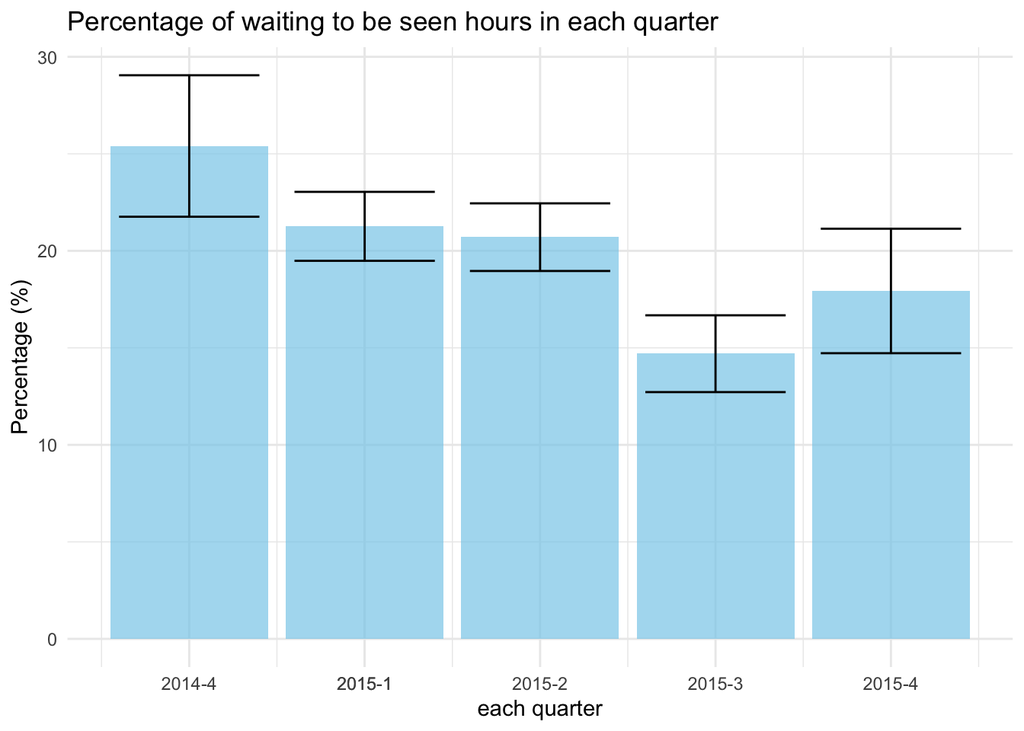

**================ Average of wait time to be seen patients in each quarter ================**

```
## # A tibble: 5 × 2
##   yq        average_wtbshour
##   <yearqtr>            <dbl>
## 1 2014 Q4                 19
## 2 2015 Q1                 15
## 3 2015 Q2                 14
## 4 2015 Q3                  8
## 5 2015 Q4                 12
```

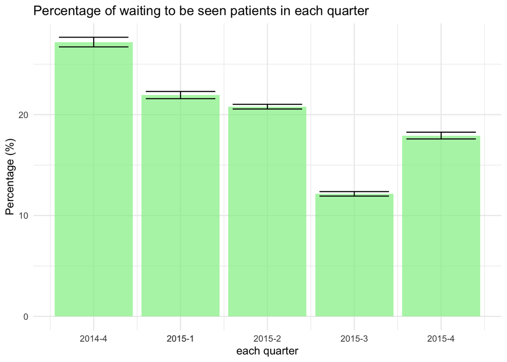

**================ Average of census patients in each quarter ================**

```
## # A tibble: 5 × 2
##   yq        average_censushour
##   <yearqtr>              <dbl>
## 1 2014 Q4                 33.7
## 2 2015 Q1                 30.7
## 3 2015 Q2                 29.0
## 4 2015 Q3                 21.2
## 5 2015 Q4                 26.8
```

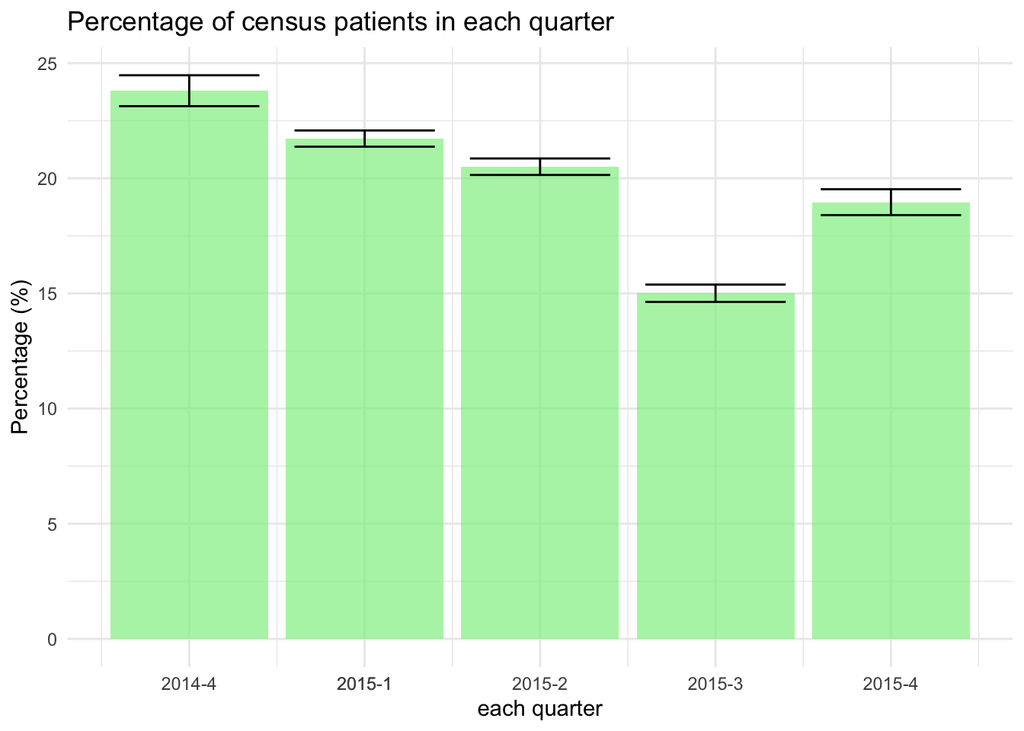

#### **1-1- Feature 1:waiting_to_be_seen hours, waiting to be seen patients, census patients**

```
##    Min. 1st Qu.  Median    Mean 3rd Qu.    Max.    NA's
##    0.00   33.00   65.00   88.64  123.00  916.00     441
```

```
##    Min. 1st Qu.  Median    Mean 3rd Qu.    Max.    NA's
##    0.00    5.00   11.00   13.77   20.00  210.00     154
```

```
##    Min. 1st Qu.  Median    Mean 3rd Qu.    Max.    NA's
##    0.00   16.00   26.00   28.48   39.00   81.00     151
```

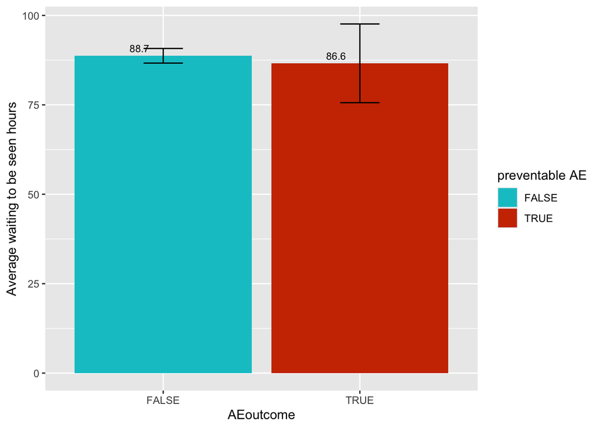

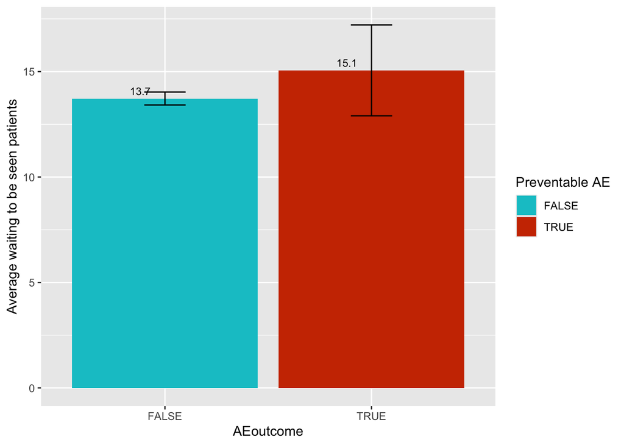

We can also plot average census patients for each type of AEoutcome as shown below: The analysis reveals that there is no significant difference in the average waiting to be seen between patients with positive and negative AE outcomes.

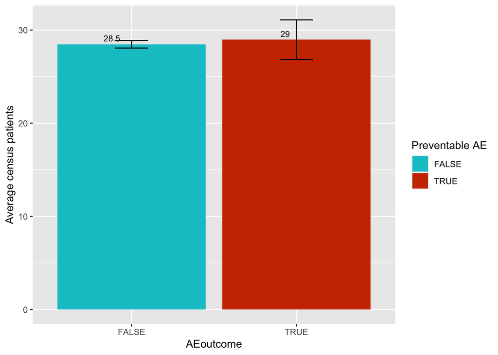

We can also plot average waiting to be seen hours for each site as shown below:

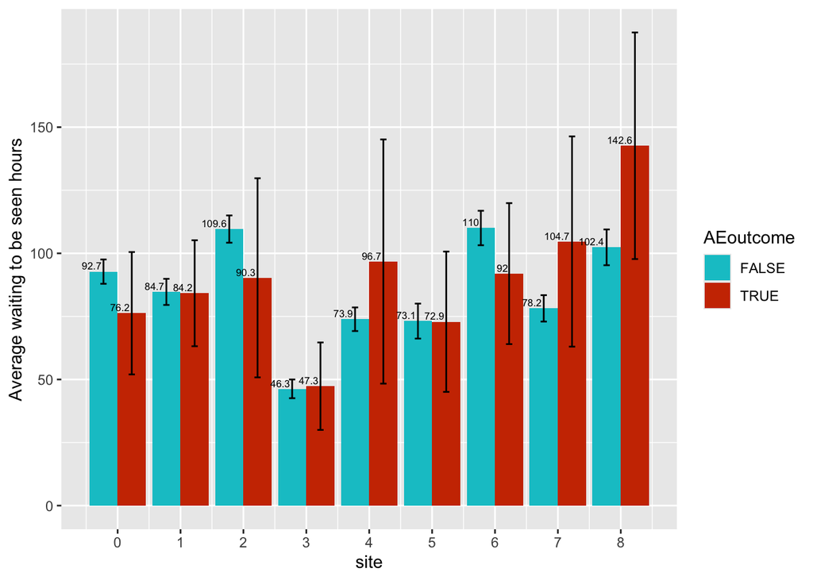

We can also plot average waiting to be seen patients for each site as shown below:

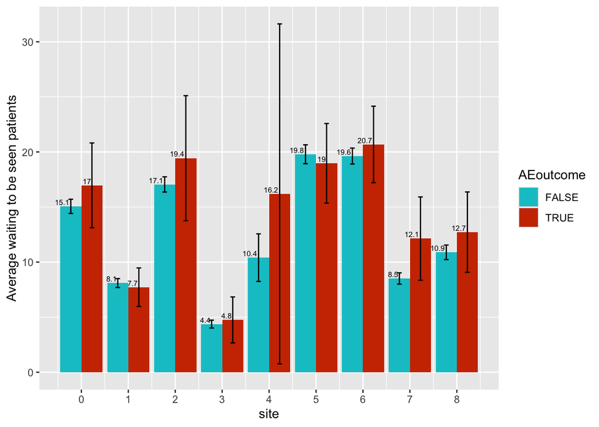

We can also plot average census patients for each site as shown below:

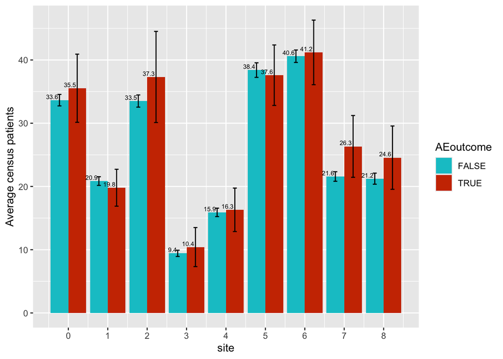

We can also plot average waiting time to be seen hours for each ctas as shown below:

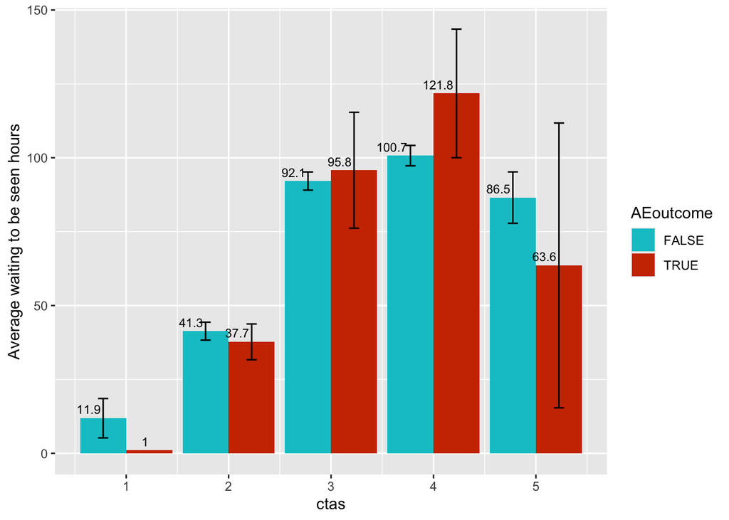

We can also plot average waiting time to be seen patients for each ctas as shown below:

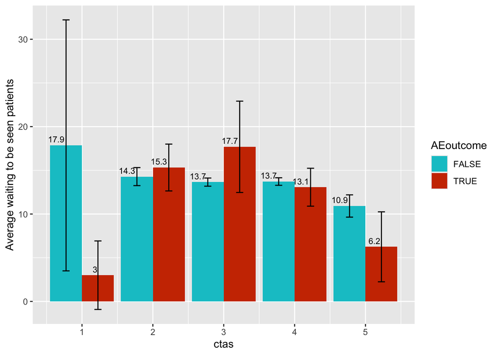

We can also plot average census patients for each ctas as shown below:

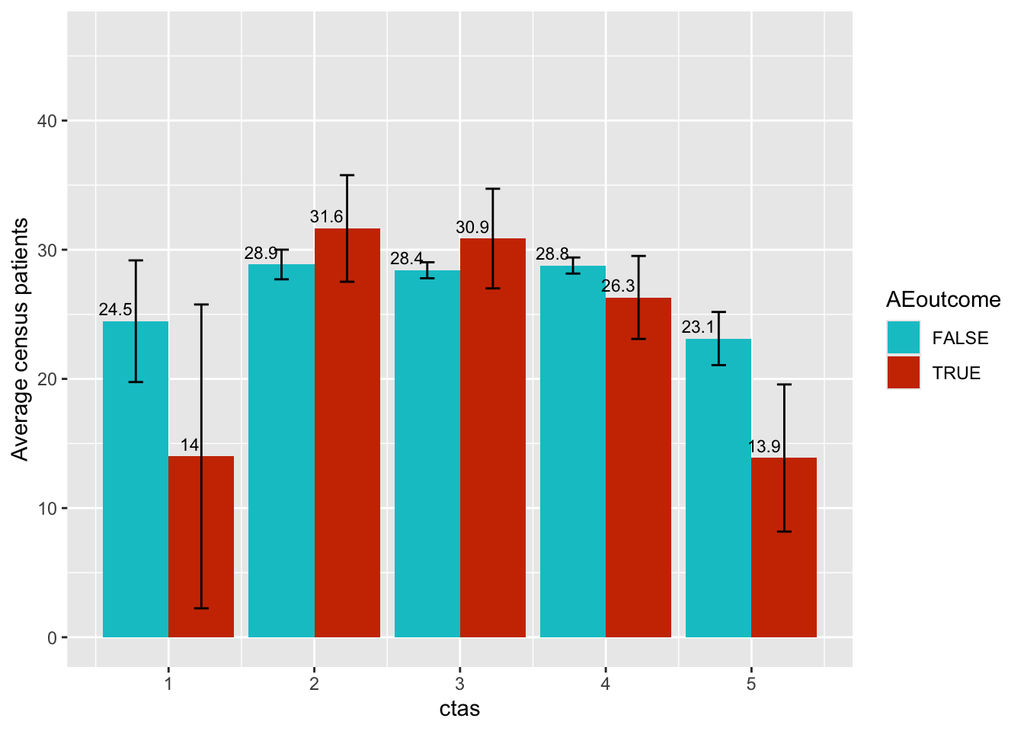

We can also plot average waiting to be seen hours for each shift_block as shown below:

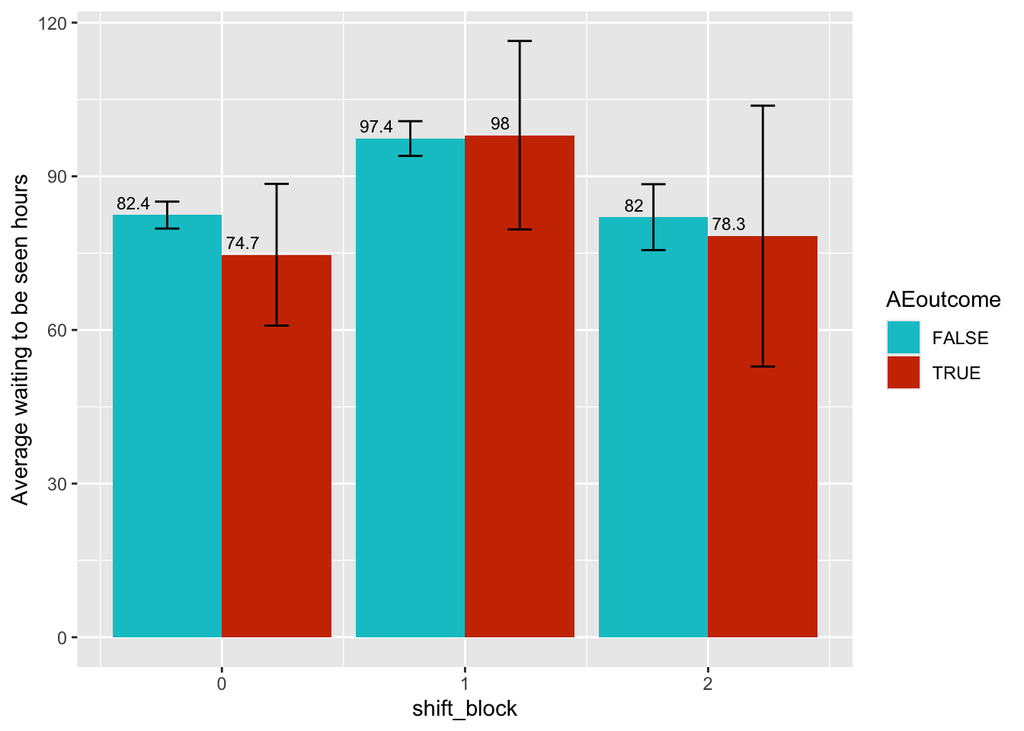

We can also plot average waiting to be seen patients for each shift_block as shown below:

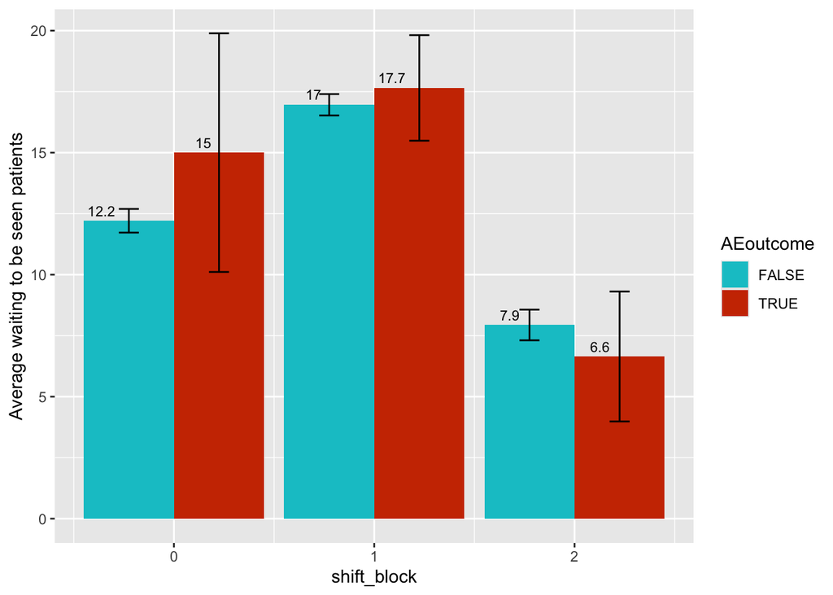

We can also plot average census patients for each shift_block as shown below:

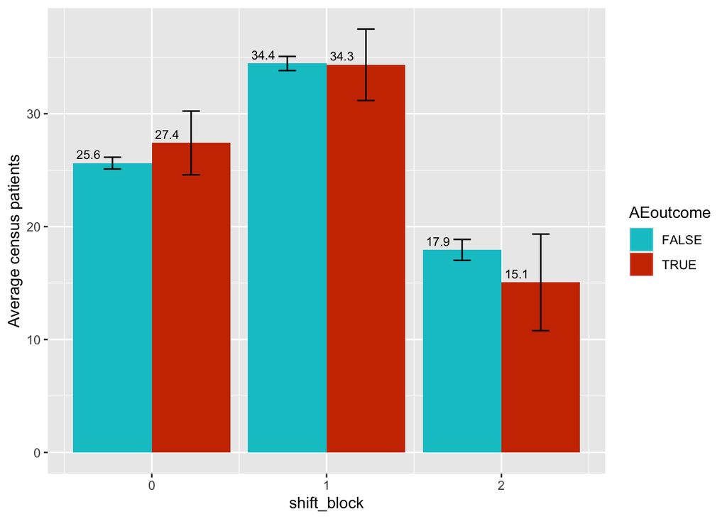

### **2- Matching**

In order to investigate the effect of **waiting to be seen** feature on **Preventable AE**, we can use matching algorithm to find similar cases with negative and positive AEoutcome, put these cases in two different groups and then investigate the relationship between waiting to be seen for matched groups. To do this, we selected features that are listed below:

- shift_block
- ageyrs
- site
- ctas
- waiting to be seen

  In order to match cases from positive and negative AEoutcome we will go through these steps:

1- Creating two pools of data. One for positive and one for negative AEoutcome **Please note that since “waiting to be seen” is the parameter of interest, there is no point to for keeping NA values, so we removed rows which contained NA in waiting to be seen column.**

2- Preparing dataset to pass it to **“Fuzzyjoin”** function

3- Using “Fuzzyjoin” for matching data:

In order to find matches between two dataframes, we are going to use “Fuzzymatch”. The procedure we decided to use for matching is explained below:

- **Exact** matching for site feature
- **Exact** matching for ctas feature
- **Exact** matching for shift_block feature
- ageyrs within the range of **-20% and +20%** is considered as match value

Below is the result of matching algorithm:

```
## # A tibble: 6,377 × 28
## # Groups:   site, shift_block, shift_date, ctas [698]
##    record_id shift_date shift_block ageyrs   sex  site   los chronic_condition
##    <chr>     <date>           <dbl>  <dbl> <dbl> <dbl> <dbl>             <dbl>
##  1 463-1     2014-11-16           0   3.92     0     0    95                 0
##  2 463-10    2014-11-16           0  10.6      0     0   147                 0
##  3 463-1000  2015-06-07           1   1.42     0     0    59                 0
##  4 463-1001  2015-06-07           1   1.08     0     0   441                 1
##  5 463-1003  2015-06-07           1   2.75     0     0   247                 1
##  6 463-1005  2015-06-07           1  16        0     0   197                 0
##  7 463-1007  2015-06-07           1   6.08     0     0    79                 0
##  8 463-1009  2015-06-07           1   2.75     0     0    74                 0
##  9 463-1010  2015-06-07           1   2.92     1     0    81                 0
## 10 463-1011  2015-06-07           1  12        0     0    89                 0
## # ℹ 6,367 more rows
## # ℹ 20 more variables: number_ed_md_involved <dbl>, number_staff <dbl>,
## #   ctas <dbl>, pt_disposition <dbl>, AEoutcome <lgl>, number_ae <dbl>,
## #   waiting_to_be_seen <dbl>, censushour <dbl>, wtbshour <dbl>, yq <yearqtr>,
## #   avg_waiting_to_be_seen_shift <dbl>, avg_wtbshour_shift <dbl>,
## #   avg_censushour_shift <dbl>, waiting_to_be_seen_cat <chr>,
## #   shift_waiting_to_be_seen_cat <chr>, wtbshour_cat <chr>, …
```

| record_id | shift_block | ageyrs | site | ctas | waiting_to_be_seen | avg_waiting_to_be_seen_shift | shift_waiting_to_be_seen_cat | number_ae | AEoutcome | ageyrs_start | ageyrs_end | record_id_n | shift_block_n | ageyrs_n | site_n | ctas_n | waiting_to_be_seen_n | avg_waiting_to_be_seen_shift_n | shift_waiting_to_be_seen_cat_n | number_ae_n | AEoutcome_n |
| --- | --- | --- | --- | --- | --- | --- | --- | --- | --- | --- | --- | --- | --- | --- | --- | --- | --- | --- | --- | --- | --- |
| 463-1012 | 1 | 12 | 0 | 2 | 43 | 49.86667 | LOW | 3 | TRUE | 9.6 | 14.4 | 463-1030 | 1 | 14.00 | 0 | 2 | 79 | 49.86667 | LOW | 0 | FALSE |
| 463-1012 | 1 | 12 | 0 | 2 | 43 | 49.86667 | LOW | 3 | TRUE | 9.6 | 14.4 | 463-1046 | 1 | 14.00 | 0 | 2 | 125 | 49.86667 | LOW | 0 | FALSE |
| 463-1012 | 1 | 12 | 0 | 2 | 43 | 49.86667 | LOW | 3 | TRUE | 9.6 | 14.4 | 463-1145 | 1 | 14.25 | 0 | 2 | 60 | 44.00000 | LOW | 0 | FALSE |
| 463-1012 | 1 | 12 | 0 | 2 | 43 | 49.86667 | LOW | 3 | TRUE | 9.6 | 14.4 | 463-1160 | 1 | 10.92 | 0 | 2 | 67 | 44.00000 | LOW | 0 | FALSE |
| 463-1012 | 1 | 12 | 0 | 2 | 43 | 49.86667 | LOW | 3 | TRUE | 9.6 | 14.4 | 463-1516 | 1 | 13.00 | 0 | 2 | 20 | 36.25000 | LOW | 0 | FALSE |
| 463-1012 | 1 | 12 | 0 | 2 | 43 | 49.86667 | LOW | 3 | TRUE | 9.6 | 14.4 | 463-197 | 1 | 11.42 | 0 | 2 | 52 | 33.88889 | LOW | 0 | FALSE |
| 463-1012 | 1 | 12 | 0 | 2 | 43 | 49.86667 | LOW | 3 | TRUE | 9.6 | 14.4 | 463-418 | 1 | 14.33 | 0 | 2 | 88 | 64.69231 | LOW | 0 | FALSE |
| 463-1012 | 1 | 12 | 0 | 2 | 43 | 49.86667 | LOW | 3 | TRUE | 9.6 | 14.4 | 463-509 | 1 | 11.08 | 0 | 2 | 67 | 62.11111 | LOW | 0 | FALSE |
| 463-1012 | 1 | 12 | 0 | 2 | 43 | 49.86667 | LOW | 3 | TRUE | 9.6 | 14.4 | 463-511 | 1 | 13.08 | 0 | 2 | 43 | 62.11111 | LOW | 0 | FALSE |
| 463-1012 | 1 | 12 | 0 | 2 | 43 | 49.86667 | LOW | 3 | TRUE | 9.6 | 14.4 | 463-525 | 1 | 11.58 | 0 | 2 | 80 | 62.11111 | LOW | 0 | FALSE |

```
##
##  Welch Two Sample t-test
##
## data:  waiting_to_be_seen by AEoutcome
## t = -4.7018, df = 4402.7, p-value = 2.658e-06
## alternative hypothesis: true difference in means between group FALSE and group TRUE is not equal to 0
## 95 percent confidence interval:
##  -18.039980  -7.422774
## sample estimates:
## mean in group FALSE  mean in group TRUE
##            93.72144           106.45282
```

In the above table, the first 12 columns are related to positive AEoutcome group and the next columns are found matches from negative AEoutcome group. **Note that for one observation from positive AEoutcome group, we can have more than 1 match from negative AEoutcome group**. Since for each observation we can have multiple matches, we took an average from “waiting to be seen” of matches. Now we can compare the average “waiting to be seen” for different groups (negative and positive AEoutcome).

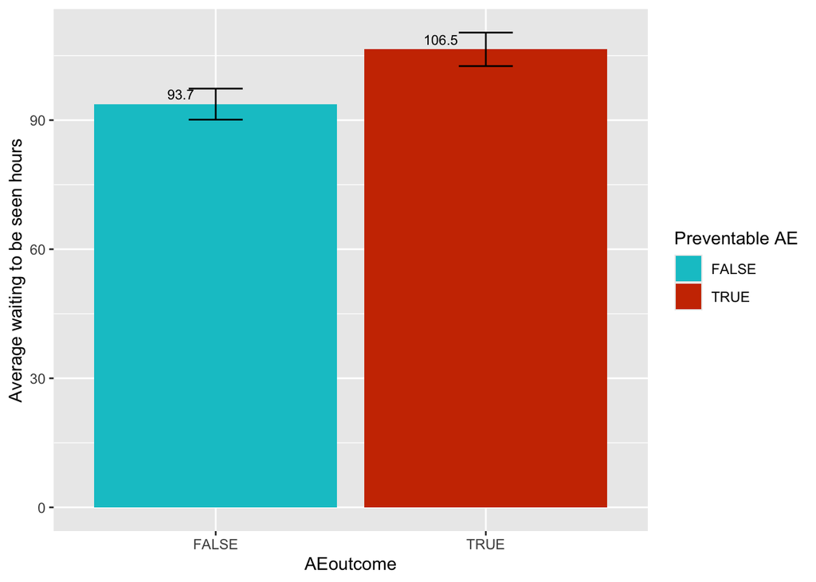

We can also compare the average waiting to be seen for matched data for different ctas:

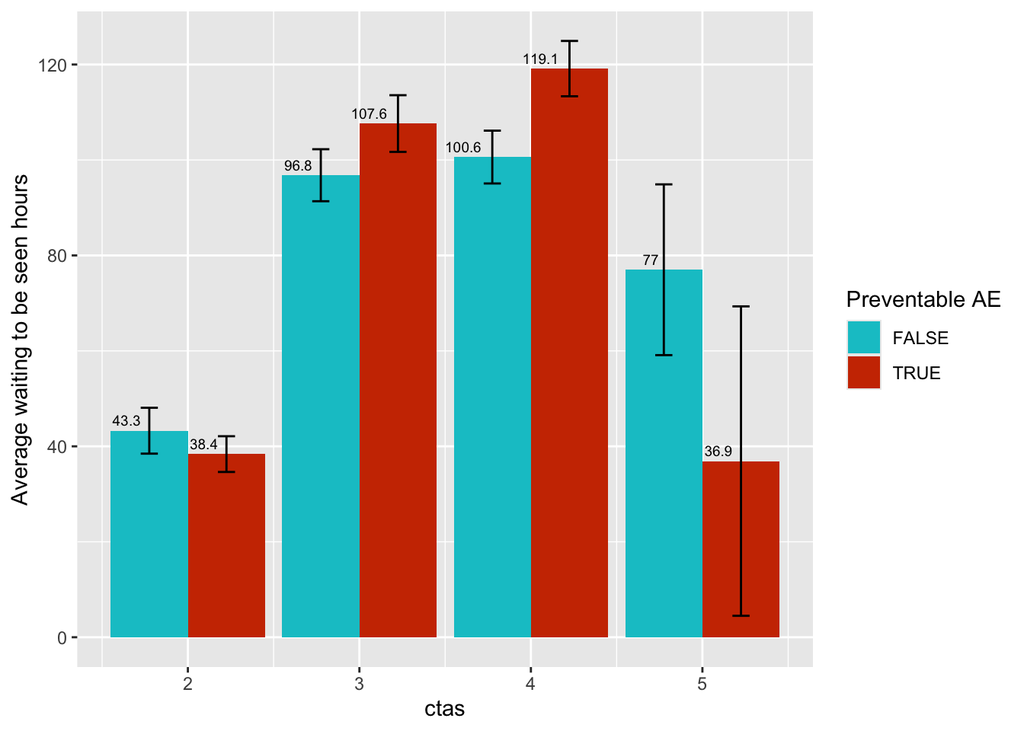

We can investigate the same concept for each shift block and compare the average waiting to be seen for different group. The result is presented below:

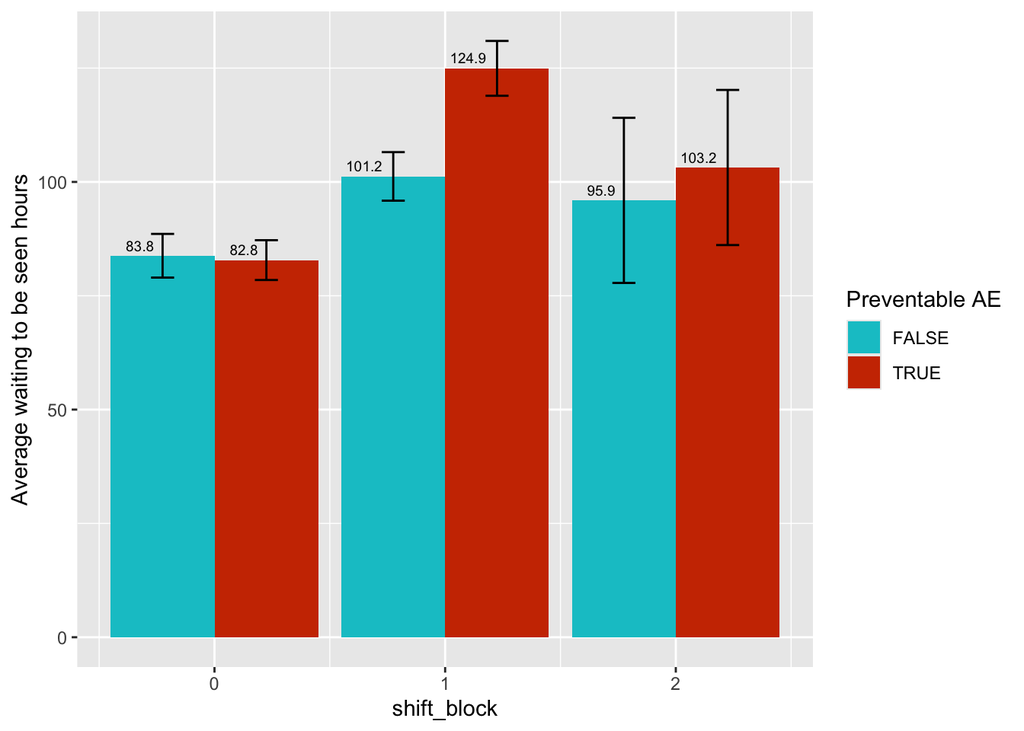

We can also check this for each site. The result is presented below:

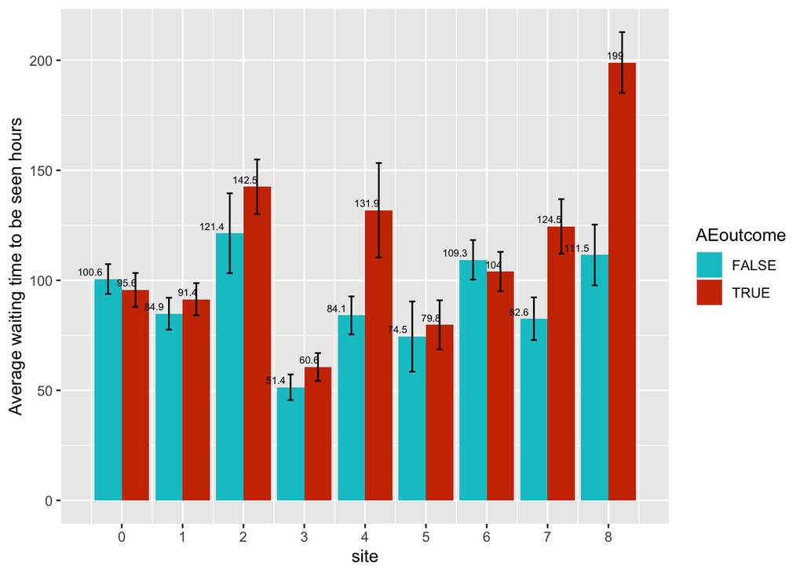

### **2- Matching**

```
## # A tibble: 6,377 × 28
## # Groups:   site, shift_block, shift_date, ctas [698]
##    record_id shift_date shift_block ageyrs   sex  site   los chronic_condition
##    <chr>     <date>           <dbl>  <dbl> <dbl> <dbl> <dbl>             <dbl>
##  1 463-1     2014-11-16           0   3.92     0     0    95                 0
##  2 463-10    2014-11-16           0  10.6      0     0   147                 0
##  3 463-1000  2015-06-07           1   1.42     0     0    59                 0
##  4 463-1001  2015-06-07           1   1.08     0     0   441                 1
##  5 463-1003  2015-06-07           1   2.75     0     0   247                 1
##  6 463-1005  2015-06-07           1  16        0     0   197                 0
##  7 463-1007  2015-06-07           1   6.08     0     0    79                 0
##  8 463-1009  2015-06-07           1   2.75     0     0    74                 0
##  9 463-1010  2015-06-07           1   2.92     1     0    81                 0
## 10 463-1011  2015-06-07           1  12        0     0    89                 0
## # ℹ 6,367 more rows
## # ℹ 20 more variables: number_ed_md_involved <dbl>, number_staff <dbl>,
## #   ctas <dbl>, pt_disposition <dbl>, AEoutcome <lgl>, number_ae <dbl>,
## #   waiting_to_be_seen <dbl>, censushour <dbl>, wtbshour <dbl>, yq <yearqtr>,
## #   avg_waiting_to_be_seen_shift <dbl>, avg_wtbshour_shift <dbl>,
## #   avg_censushour_shift <dbl>, waiting_to_be_seen_cat <chr>,
## #   shift_waiting_to_be_seen_cat <chr>, wtbshour_cat <chr>, …
```

| record_id | shift_block | ageyrs | site | ctas | wtbshour | avg_wtbshour_shift | shift_wtbshour_cat | number_ae | AEoutcome | ageyrs_start | ageyrs_end | record_id_n | shift_block_n | ageyrs_n | site_n | ctas_n | wtbshour_n | avg_wtbshour_shift_n | shift_wtbshour_cat_n | number_ae_n | AEoutcome_n |
| --- | --- | --- | --- | --- | --- | --- | --- | --- | --- | --- | --- | --- | --- | --- | --- | --- | --- | --- | --- | --- | --- |
| 463-1012 | 1 | 12 | 0 | 2 | 13 | 16.33333 | TRUE | 3 | TRUE | 9.6 | 14.4 | 463-1030 | 1 | 14.00 | 0 | 2 | 18 | 16.33333 | TRUE | 0 | FALSE |
| 463-1012 | 1 | 12 | 0 | 2 | 13 | 16.33333 | TRUE | 3 | TRUE | 9.6 | 14.4 | 463-1046 | 1 | 14.00 | 0 | 2 | 21 | 16.33333 | TRUE | 0 | FALSE |
| 463-1012 | 1 | 12 | 0 | 2 | 13 | 16.33333 | TRUE | 3 | TRUE | 9.6 | 14.4 | 463-1145 | 1 | 14.25 | 0 | 2 | 7 | 13.42857 | TRUE | 0 | FALSE |
| 463-1012 | 1 | 12 | 0 | 2 | 13 | 16.33333 | TRUE | 3 | TRUE | 9.6 | 14.4 | 463-1160 | 1 | 10.92 | 0 | 2 | 8 | 13.42857 | TRUE | 0 | FALSE |
| 463-1012 | 1 | 12 | 0 | 2 | 13 | 16.33333 | TRUE | 3 | TRUE | 9.6 | 14.4 | 463-1516 | 1 | 13.00 | 0 | 2 | 10 | 13.62500 | TRUE | 0 | FALSE |
| 463-1012 | 1 | 12 | 0 | 2 | 13 | 16.33333 | TRUE | 3 | TRUE | 9.6 | 14.4 | 463-197 | 1 | 11.42 | 0 | 2 | 17 | 21.55556 | TRUE | 0 | FALSE |
| 463-1012 | 1 | 12 | 0 | 2 | 13 | 16.33333 | TRUE | 3 | TRUE | 9.6 | 14.4 | 463-418 | 1 | 14.33 | 0 | 2 | 28 | 23.07692 | TRUE | 0 | FALSE |
| 463-1012 | 1 | 12 | 0 | 2 | 13 | 16.33333 | TRUE | 3 | TRUE | 9.6 | 14.4 | 463-509 | 1 | 11.08 | 0 | 2 | 32 | 27.33333 | TRUE | 0 | FALSE |
| 463-1012 | 1 | 12 | 0 | 2 | 13 | 16.33333 | TRUE | 3 | TRUE | 9.6 | 14.4 | 463-511 | 1 | 13.08 | 0 | 2 | 32 | 27.33333 | TRUE | 0 | FALSE |
| 463-1012 | 1 | 12 | 0 | 2 | 13 | 16.33333 | TRUE | 3 | TRUE | 9.6 | 14.4 | 463-525 | 1 | 11.58 | 0 | 2 | 44 | 27.33333 | TRUE | 0 | FALSE |

```
##
##  Welch Two Sample t-test
##
## data:  wtbshour by AEoutcome
## t = -6.2291, df = 3713.4, p-value = 5.216e-10
## alternative hypothesis: true difference in means between group FALSE and group TRUE is not equal to 0
## 95 percent confidence interval:
##  -4.330435 -2.257024
## sample estimates:
## mean in group FALSE  mean in group TRUE
##            15.31683            18.61056
```

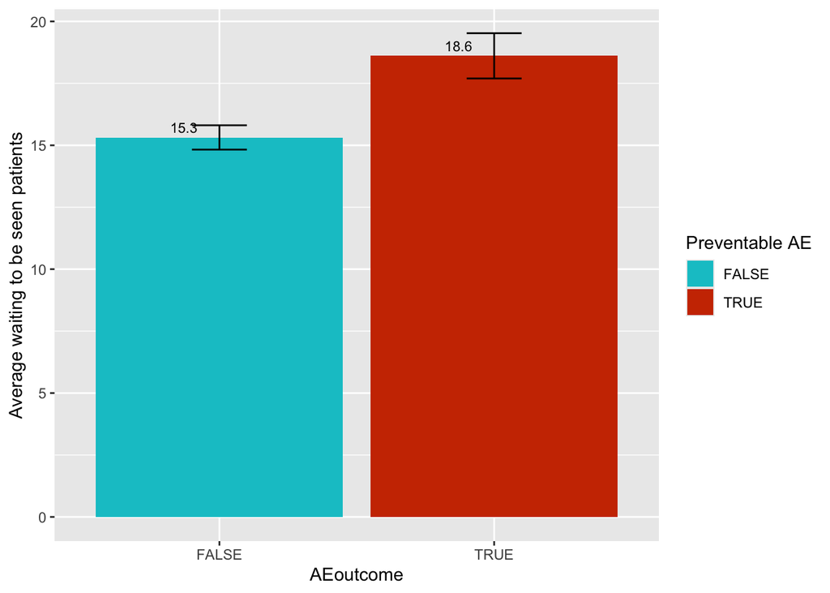

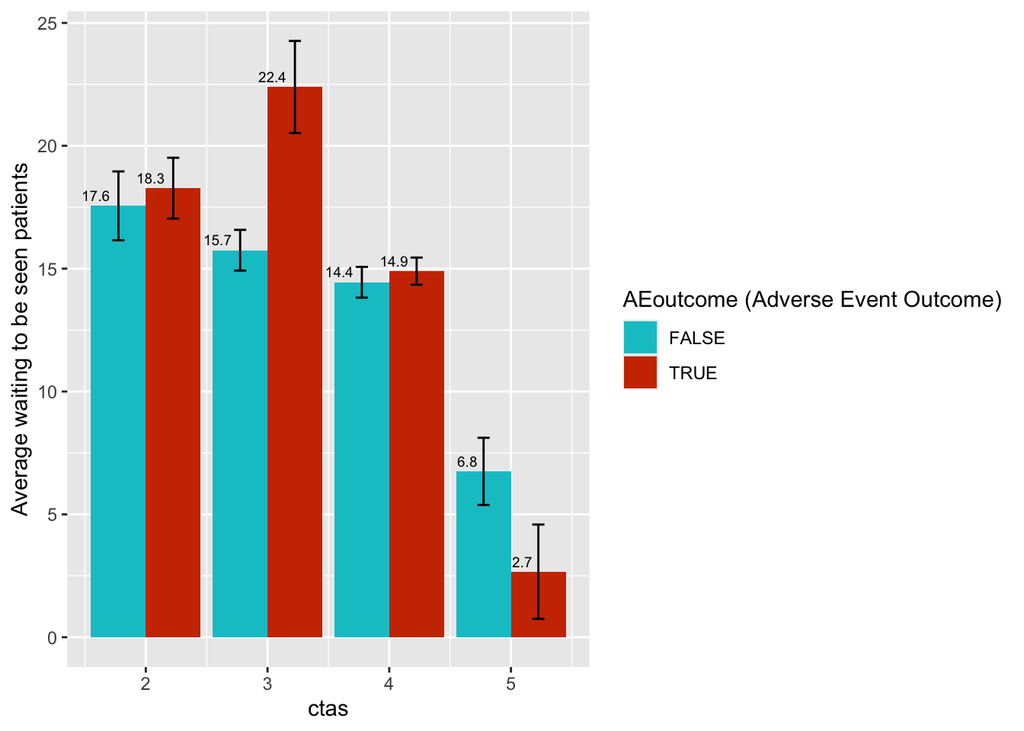

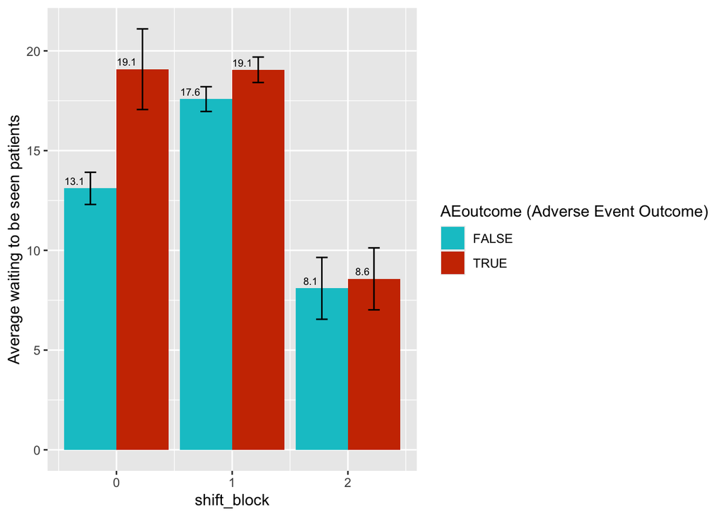

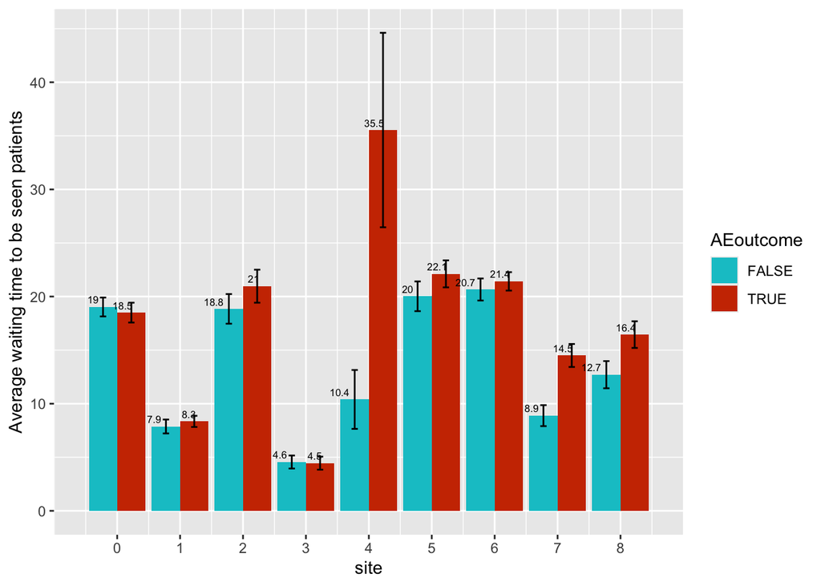

### **2- Matching**

```
## # A tibble: 6,377 × 28
## # Groups:   site, shift_block, shift_date, ctas [698]
##    record_id shift_date shift_block ageyrs   sex  site   los chronic_condition
##    <chr>     <date>           <dbl>  <dbl> <dbl> <dbl> <dbl>             <dbl>
##  1 463-1     2014-11-16           0   3.92     0     0    95                 0
##  2 463-10    2014-11-16           0  10.6      0     0   147                 0
##  3 463-1000  2015-06-07           1   1.42     0     0    59                 0
##  4 463-1001  2015-06-07           1   1.08     0     0   441                 1
##  5 463-1003  2015-06-07           1   2.75     0     0   247                 1
##  6 463-1005  2015-06-07           1  16        0     0   197                 0
##  7 463-1007  2015-06-07           1   6.08     0     0    79                 0
##  8 463-1009  2015-06-07           1   2.75     0     0    74                 0
##  9 463-1010  2015-06-07           1   2.92     1     0    81                 0
## 10 463-1011  2015-06-07           1  12        0     0    89                 0
## # ℹ 6,367 more rows
## # ℹ 20 more variables: number_ed_md_involved <dbl>, number_staff <dbl>,
## #   ctas <dbl>, pt_disposition <dbl>, AEoutcome <lgl>, number_ae <dbl>,
## #   waiting_to_be_seen <dbl>, censushour <dbl>, wtbshour <dbl>, yq <yearqtr>,
## #   avg_waiting_to_be_seen_shift <dbl>, avg_wtbshour_shift <dbl>,
## #   avg_censushour_shift <dbl>, waiting_to_be_seen_cat <chr>,
## #   shift_waiting_to_be_seen_cat <chr>, wtbshour_cat <chr>, …
```

| record_id | shift_block | ageyrs | site | ctas | censushour | avg_censushour_shift | shift_censushour_cat | number_ae | AEoutcome | ageyrs_start | ageyrs_end | record_id_n | shift_block_n | ageyrs_n | site_n | ctas_n | censushour_n | avg_censushour_shift_n | shift_censushour_cat_n | number_ae_n | AEoutcome_n |
| --- | --- | --- | --- | --- | --- | --- | --- | --- | --- | --- | --- | --- | --- | --- | --- | --- | --- | --- | --- | --- | --- |
| 463-1012 | 1 | 12 | 0 | 2 | 35 | 37.93333 | TRUE | 3 | TRUE | 9.6 | 14.4 | 463-1030 | 1 | 14.00 | 0 | 2 | 37 | 37.93333 | TRUE | 0 | FALSE |
| 463-1012 | 1 | 12 | 0 | 2 | 35 | 37.93333 | TRUE | 3 | TRUE | 9.6 | 14.4 | 463-1046 | 1 | 14.00 | 0 | 2 | 36 | 37.93333 | TRUE | 0 | FALSE |
| 463-1012 | 1 | 12 | 0 | 2 | 35 | 37.93333 | TRUE | 3 | TRUE | 9.6 | 14.4 | 463-1145 | 1 | 14.25 | 0 | 2 | 28 | 36.00000 | TRUE | 0 | FALSE |
| 463-1012 | 1 | 12 | 0 | 2 | 35 | 37.93333 | TRUE | 3 | TRUE | 9.6 | 14.4 | 463-1160 | 1 | 10.92 | 0 | 2 | 33 | 36.00000 | TRUE | 0 | FALSE |
| 463-1012 | 1 | 12 | 0 | 2 | 35 | 37.93333 | TRUE | 3 | TRUE | 9.6 | 14.4 | 463-1516 | 1 | 13.00 | 0 | 2 | 35 | 39.00000 | TRUE | 0 | FALSE |
| 463-1012 | 1 | 12 | 0 | 2 | 35 | 37.93333 | TRUE | 3 | TRUE | 9.6 | 14.4 | 463-197 | 1 | 11.42 | 0 | 2 | 31 | 36.55556 | TRUE | 0 | FALSE |
| 463-1012 | 1 | 12 | 0 | 2 | 35 | 37.93333 | TRUE | 3 | TRUE | 9.6 | 14.4 | 463-418 | 1 | 14.33 | 0 | 2 | 56 | 47.46154 | TRUE | 0 | FALSE |
| 463-1012 | 1 | 12 | 0 | 2 | 35 | 37.93333 | TRUE | 3 | TRUE | 9.6 | 14.4 | 463-509 | 1 | 11.08 | 0 | 2 | 57 | 49.11111 | TRUE | 0 | FALSE |
| 463-1012 | 1 | 12 | 0 | 2 | 35 | 37.93333 | TRUE | 3 | TRUE | 9.6 | 14.4 | 463-511 | 1 | 13.08 | 0 | 2 | 57 | 49.11111 | TRUE | 0 | FALSE |
| 463-1012 | 1 | 12 | 0 | 2 | 35 | 37.93333 | TRUE | 3 | TRUE | 9.6 | 14.4 | 463-525 | 1 | 11.58 | 0 | 2 | 66 | 49.11111 | TRUE | 0 | FALSE |

```
##
##  Welch Two Sample t-test
##
## data:  censushour by AEoutcome
## t = -2.3978, df = 4840.5, p-value = 0.01653
## alternative hypothesis: true difference in means between group FALSE and group TRUE is not equal to 0
## 95 percent confidence interval:
##  -2.0403254 -0.2047241
## sample estimates:
## mean in group FALSE  mean in group TRUE
##            31.47566            32.59818
```

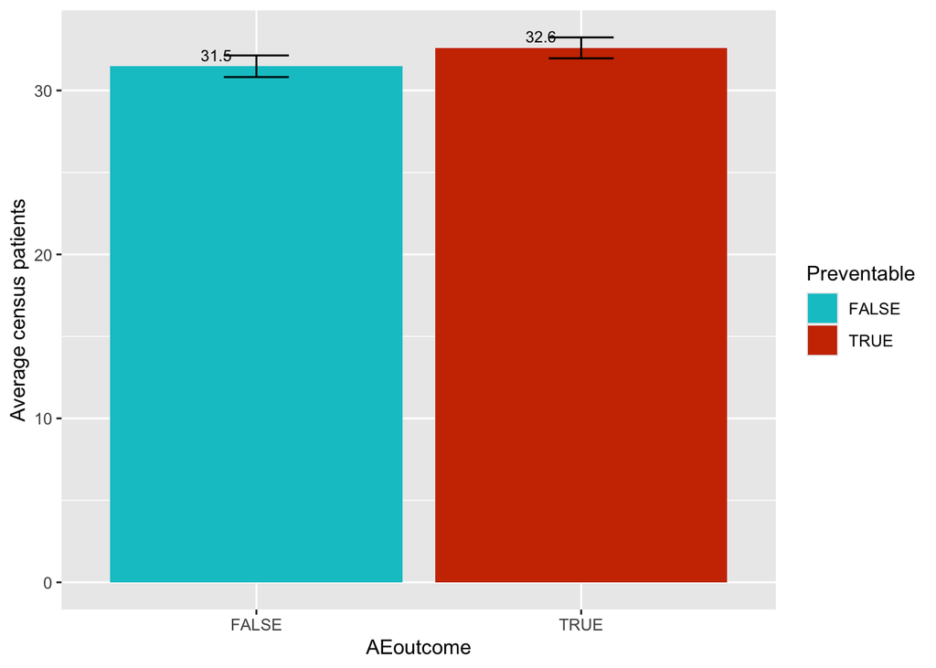

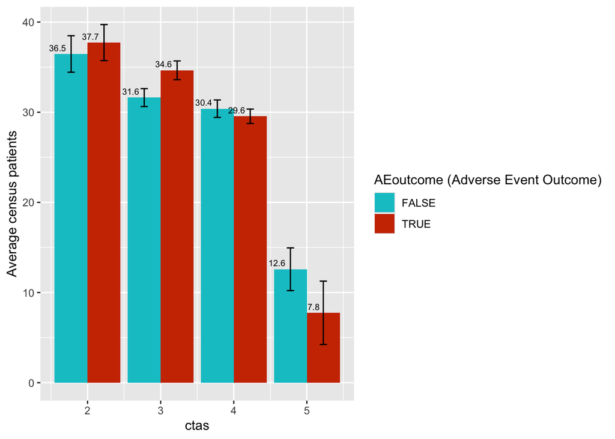

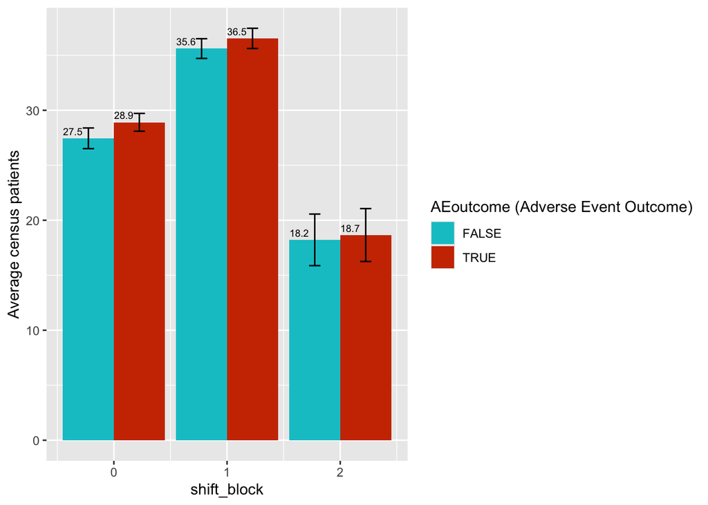

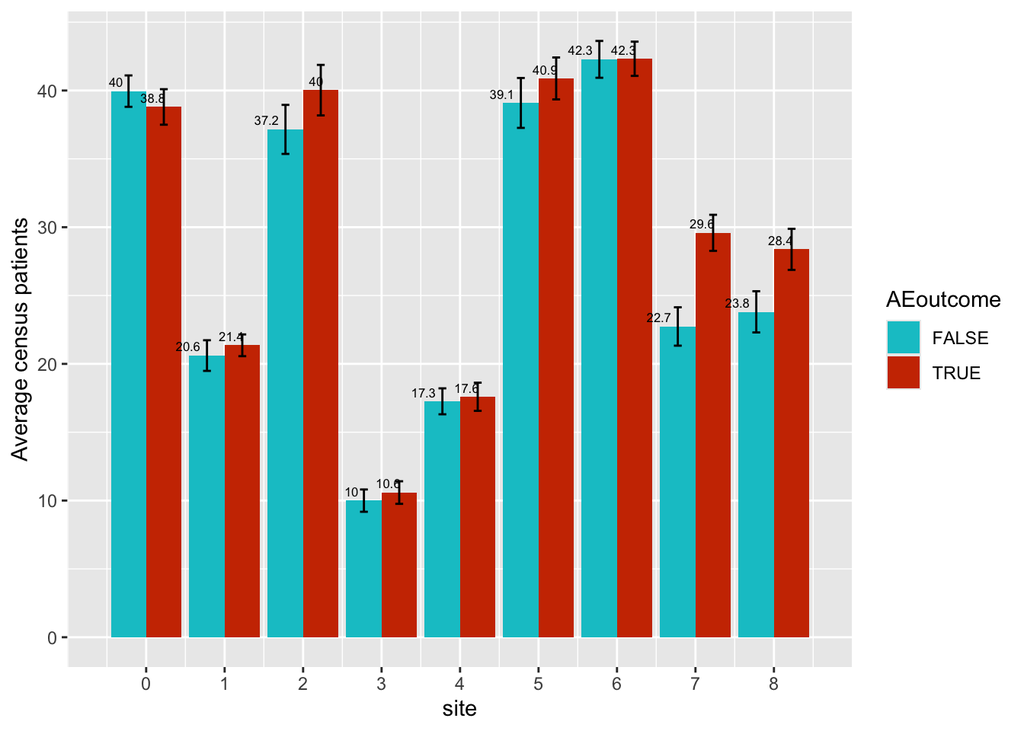